# 2021 Version of the Multi-level Lockdown Model

Andrew Mitchell

## Reporting

We will be using the TRIPOD (Transparent reporting of multivariable prediction model for individual prognosis or diagnosis) framework for reporting the model development, validation, and results.

## Outcome

### 6a Clearly define the outcome that is predicted by the prediction model, including how and when assessed.

This study involves predicting five outcome variables, through five separately constructed models. These outcomes are survey responses as collected according to the SSID protocol through in-situ questionnaires in various urban public spaces. The five outcome variables are:

1. `Pleasant` - from (-1, 1) derived from the 8 PAQs according to ISO 12913 Part 3
2. `Eventful` - from (-1, 1) derived from the 8 PAQs according to ISO 12913 Part 3
3. `Human` - from (1, 5) survey response regarding the relative presence/dominance of human sounds
4. `Traffic` - from (1, 5) survey response regarding the relative presence/dominance of traffic sounds
5. `Natural` - from (1, 5) survey response regarding the relative presence/dominance of natural sounds

### 6b Report any actions to blind assessment of the outcome to be predicted

N/A

## Predictors

### 7a Clearly define all predictors used in developing or validating the multivariable prediction model, including how and when they were measured.

The acoustic predictors are derived from the 30s binaural recordings taken during the SSID Protocol. The (psycho)acoustic metrics considered are:

```r
features <- c("N_5", "S", "R", "I", "FS", "LAeq", "LAeq_10_LAeq_90", "LCeq_LAeq", "SIL_50", "PeakSpectralCentroid")
feature_string <- paste(features, collapse = " + ")
feature_string
```

```
## [1] "N_5 + S + R + I + FS + LAeq + LAeq_10_LAeq_90 + LCeq_LAeq + SIL_50 + PeakSpectralCentroid"
```

## Sample Size

### 8 Explain how the study size was arrived at.

(Covered in the manuscript already)

```r
library(readr)
library(glue)
library(tidyr)
library(here)
library(knitr)
library(dplyr)


data <- read_csv(here("data", "2021-04-16", "LondonVeniceBINResults_2020-08-13_4.csv"))
data <- as_tibble(data)
data["LCeq_LAeq"] <- data$LCeq - data$LAeq
data <- data[c("GroupID", "LocationID", "Lockdown", "Pleasant", "Eventful", "Human", "Traffic", "Natural", features)]

print("Full data table has dimensions: ")
```

```
## [1] "Full data table has dimensions: "
```

```r
print(dim(data))
```

```
## [1] 1715   18
```

```r
print(data)
```

```
## # A tibble: 1,715 x 18
##    GroupID LocationID Lockdown Pleasant Eventful Human Traffic Natural   N_5
##    <chr>   <chr>         <dbl>    <dbl>    <dbl> <dbl>   <dbl>   <dbl> <dbl>
##  1 CT101   CamdenTown        1  -0.220     0.427     3       4       2  31.1
##  2 CT101   CamdenTown        1   0         0.25      2       3       1  31.1
##  3 CT101   CamdenTown        1  -0.470     0.177     4       4       2  31.1
##  4 CT102   CamdenTown        1   0.104    -0.75      4       3       1  34.5
##  5 CT103   CamdenTown        1   0.25      0.75      4       4       1  24.7
##  6 CT104   CamdenTown        1   0.0732    0.677     2       4       1  38.7
##  7 CT107   CamdenTown        1   0.0732    0.366     3       4       2  29.3
##  8 CT108   CamdenTown        1  -0.146     0.146     2       3       1  34.3
##  9 CT109   CamdenTown        1   0.104     1         5       4       1  30.1
## 10 CT109   CamdenTown        1  -0.116     0.323     3       3       1  30.1
## # ... with 1,705 more rows, and 9 more variables: S <dbl>, R <dbl>, I <dbl>,
## #   FS <dbl>, LAeq <dbl>, LAeq_10_LAeq_90 <dbl>, LCeq_LAeq <dbl>, SIL_50 <dbl>,
## #   PeakSpectralCentroid <dbl>
```

## Missing Data

### 9 Describe how missing data were handled (e.g. complete-case analysis, single imputation, multiple imputation) with details of any imputation method

#### Dealing with PAQ missing data

According to our data quality rules, any survey responses with more than half of the PAQ responses missing were excluded whole-sale. Otherwise, where PAQ responses are missing, they are given a value of 3 (Neutral) prior to the ISO trigonometric projection to the complex Pleasantness and Eventfulness values.

#### Missing Sound Source data

Survey responses missing a response for the target outcome are excluded only from that model. e.g. a response may be missing only the Natural sound question - it is excluded only from the Natural model and will be included in all other models (e.g. Traffic, Human, Pleasant,)

## Statistical Analysis Methods

### 10a Describe how predictors were handled in the analyses

```r
data <- data %>% mutate_at(vars(GroupID, LocationID, Lockdown), funs(as.factor))
data <- data %>% mutate_at(vars(c("Pleasant", "Eventful", "Traffic", "Human", "Natural", features)), funs(as.numeric))
kable(head(data))
```

| GroupID | LocationID | Lockdown | Pleasant | Eventful | Human | Traffic | Natural | N_5 | S | R | I | FS | LAeq | LAeq_10_LAeq_90 | LCeq_LAeq | SIL_50 | PeakSpectralCentroid |
| --- | --- | --- | --- | --- | --- | --- | --- | --- | --- | --- | --- | --- | --- | --- | --- | --- | --- |
| CT101 | CamdenTown | 1 | -0.2196699 | 0.4267767 | 3 | 4 | 2 | 31.1 | 2.15 | 0.0374 | 0.358 | 0.01700 | 70.07 | 7.78 | 7.81 | 61.32 | 2692.19 |
| CT101 | CamdenTown | 1 | 0.0000000 | 0.2500000 | 2 | 3 | 1 | 31.1 | 2.15 | 0.0374 | 0.358 | 0.01700 | 70.07 | 7.78 | 7.81 | 61.32 | 2692.19 |
| CT101 | CamdenTown | 1 | -0.4696699 | 0.1767767 | 4 | 4 | 2 | 31.1 | 2.15 | 0.0374 | 0.358 | 0.01700 | 70.07 | 7.78 | 7.81 | 61.32 | 2692.19 |
| CT102 | CamdenTown | 1 | 0.1035534 | -0.7500000 | 4 | 3 | 1 | 34.5 | 2.19 | 0.0446 | 0.362 | 0.01790 | 71.26 | 8.38 | 6.25 | 61.67 | 2563.22 |
| CT103 | CamdenTown | 1 | 0.2500000 | 0.7500000 | 4 | 4 | 1 | 24.7 | 2.00 | 0.0369 | 0.370 | 0.00889 | 66.71 | 4.23 | 7.61 | 57.94 | 2564.46 |
| CT104 | CamdenTown | 1 | 0.0732233 | 0.6767767 | 2 | 4 | 1 | 38.7 | 2.38 | 0.0413 | 0.393 | 0.01460 | 72.47 | 6.97 | 6.32 | 63.67 | 2633.38 |

### 10b Specify type of model, all model-building procedures (including any predictor selection), and method for internal validation.

#### Train-test split

We use an 80/20 train/test split. The splits are balanced within each LocationID so that we are randomly sampling from each location equally.

```r
prelockdownData <- data %>% filter(Lockdown == 1)
lockdownData <- data %>% filter(Lockdown == 2)

prelockdownData[c(features)] <- scale(prelockdownData[c(features)])

# Train-test split
library(groupdata2)
set.seed(42)

parts = partition(prelockdownData, p=0.2, cat_col="LocationID")

train = parts[[2]]
test = parts[[1]]
kable(summary(train))
```

|  | GroupID | LocationID | Lockdown | Pleasant | Eventful | Human | Traffic | Natural | N_5 | S | R | I | FS | LAeq | LAeq_10_LAeq_90 | LCeq_LAeq | SIL_50 | PeakSpectralCentroid |
| --- | --- | --- | --- | --- | --- | --- | --- | --- | --- | --- | --- | --- | --- | --- | --- | --- | --- | --- |
|  | PL107 : 19 | RussellSq :120 | 1:917 | Min. :-0.85355 | Min. :-0.75000 | Min. :1.000 | Min. :1.000 | Min. :1.000 | Min. :-1.39732 | Min. :-1.4435 | Min. :-1.75528 | Min. :-2.68134 | Min. :-0.97265 | Min. :-2.23597 | Min. :-1.69635 | Min. :-2.19618 | Min. :-2.11827 | Min. :-2.91760 |
|  | RS324 : 6 | TateModern :101 | 2: 0 | 1st Qu.:-0.03033 | 1st Qu.:-0.07322 | 1st Qu.:2.000 | 1st Qu.:2.000 | 1st Qu.:2.000 | 1st Qu.:-0.67708 | 1st Qu.:-0.7233 | 1st Qu.:-0.58145 | 1st Qu.:-0.70895 | 1st Qu.:-0.51055 | 1st Qu.:-0.63247 | 1st Qu.:-0.58095 | 1st Qu.:-0.68407 | 1st Qu.:-0.65361 | 1st Qu.:-0.68895 |
|  | CT412 : 5 | RegentsParkFields: 88 | NA | Median : 0.31066 | Median : 0.13388 | Median :3.000 | Median :3.000 | Median :2.000 | Median :-0.19385 | Median :-0.2500 | Median :-0.18151 | Median :-0.12256 | Median :-0.24002 | Median : 0.01194 | Median :-0.08178 | Median :-0.02719 | Median : 0.01898 | Median :-0.01486 |
|  | RS325 : 5 | SanMarco : 80 | NA | Mean : 0.26667 | Mean : 0.13863 | Mean :3.123 | Mean :2.668 | Mean :2.526 | Mean :-0.00836 | Mean :-0.0063 | Mean :-0.00292 | Mean : 0.00258 | Mean :-0.01097 | Mean :-0.00660 | Mean :-0.00336 | Mean : 0.00542 | Mean :-0.00423 | Mean :-0.00770 |
|  | ET306 : 4 | EustonTap : 76 | NA | 3rd Qu.: 0.60355 | 3rd Qu.: 0.35355 | 3rd Qu.:4.000 | 3rd Qu.:4.000 | 3rd Qu.:3.000 | 3rd Qu.: 0.48607 | 3rd Qu.: 0.3828 | 3rd Qu.: 0.36385 | 3rd Qu.: 0.53046 | 3rd Qu.: 0.20027 | 3rd Qu.: 0.66407 | 3rd Qu.: 0.45127 | 3rd Qu.: 0.69832 | 3rd Qu.: 0.78893 | 3rd Qu.: 0.60086 |
|  | ML103 : 4 | TorringtonSq : 72 | NA | Max. : 1.00000 | Max. : 1.00000 | Max. :5.000 | Max. :5.000 | Max. :5.000 | Max. : 5.67291 | Max. : 5.8825 | Max. : 9.51560 | Max. : 9.48619 | Max. :11.53057 | Max. : 3.36582 | Max. : 5.07004 | Max. : 3.71349 | Max. : 3.61500 | Max. : 4.08993 |
|  | (Other):874 | (Other) :380 | NA | NA’s :3 | NA’s :3 | NA’s :1 | NA’s :1 | NA’s :1 | NA’s :35 | NA’s :35 | NA’s :35 | NA’s :35 | NA’s :35 | NA’s :35 | NA | NA’s :35 | NA’s :35 | NA’s :35 |

```r
kable(summary(test))
```

|  | GroupID | LocationID | Lockdown | Pleasant | Eventful | Human | Traffic | Natural | N_5 | S | R | I | FS | LAeq | LAeq_10_LAeq_90 | LCeq_LAeq | SIL_50 | PeakSpectralCentroid |
| --- | --- | --- | --- | --- | --- | --- | --- | --- | --- | --- | --- | --- | --- | --- | --- | --- | --- | --- |
|  | PL107 : 6 | RussellSq :29 | 1:223 | Min. :-1.00000 | Min. :-0.6768 | Min. :1.000 | Min. :1.000 | Min. :1.000 | Min. :-1.38760 | Min. :-1.27888 | Min. :-1.69295 | Min. :-1.41528 | Min. :-0.90309 | Min. :-2.10231 | Min. :-1.69635 | Min. :-2.33796 | Min. :-2.04305 | Min. :-2.44007 |
|  | RS119 : 4 | TateModern :25 | 2: 0 | 1st Qu.:-0.07322 | 1st Qu.:-0.1036 | 1st Qu.:2.000 | 1st Qu.:2.000 | 1st Qu.:1.500 | 1st Qu.:-0.67951 | 1st Qu.:-0.72326 | 1st Qu.:-0.60222 | 1st Qu.:-0.70895 | 1st Qu.:-0.53815 | 1st Qu.:-0.68204 | 1st Qu.:-0.53011 | 1st Qu.:-0.85376 | 1st Qu.:-0.68458 | 1st Qu.:-0.58677 |
|  | ET307 : 3 | RegentsParkFields:21 | NA | Median : 0.31066 | Median : 0.1464 | Median :3.000 | Median :3.000 | Median :2.000 | Median :-0.09672 | Median :-0.27053 | Median :-0.08283 | Median :-0.09591 | Median :-0.24002 | Median : 0.10227 | Median :-0.07254 | Median : 0.01505 | Median : 0.13846 | Median : 0.01668 |
|  | ET109 : 2 | EustonTap :19 | NA | Mean : 0.24029 | Mean : 0.1502 | Mean :3.099 | Mean :2.637 | Mean :2.453 | Mean : 0.03461 | Mean : 0.02607 | Mean : 0.01208 | Mean :-0.01069 | Mean : 0.04544 | Mean : 0.02731 | Mean : 0.01382 | Mean :-0.02243 | Mean : 0.01754 | Mean : 0.03189 |
|  | ET118 : 2 | SanMarco :19 | NA | 3rd Qu.: 0.57322 | 3rd Qu.: 0.4009 | 3rd Qu.:4.000 | 3rd Qu.:3.000 | 3rd Qu.:3.000 | 3rd Qu.: 0.52492 | 3rd Qu.: 0.40857 | 3rd Qu.: 0.36385 | 3rd Qu.: 0.35721 | 3rd Qu.: 0.22925 | 3rd Qu.: 0.69124 | 3rd Qu.: 0.41275 | 3rd Qu.: 0.67268 | 3rd Qu.: 0.77565 | 3rd Qu.: 0.64600 |
|  | MG119 : 2 | TorringtonSq :18 | NA | Max. : 1.00000 | Max. : 0.9268 | Max. :5.000 | Max. :5.000 | Max. :5.000 | Max. : 5.76033 | Max. : 4.52429 | Max. : 4.60212 | Max. : 5.42146 | Max. : 8.49407 | Max. : 3.08235 | Max. : 5.38124 | Max. : 3.22479 | Max. : 2.66068 | Max. : 3.11541 |
|  | (Other):204 | (Other) :92 | NA | NA’s :2 | NA’s :3 | NA | NA | NA | NA’s :10 | NA’s :10 | NA’s :10 | NA’s :10 | NA’s :10 | NA’s :10 | NA | NA’s :10 | NA’s :10 | NA’s :10 |

## Pleasant Model

```r
Pleasant_formula <- as.formula(glue("Pleasant ~ 1 + ", feature_string, " + (1 + ", feature_string, "|LocationID)"))

init_Pleasant_model <- lmerTest::lmer(Pleasant_formula, data = train)

step_Pleasant_model <- lmerTest::step(init_Pleasant_model, data = train, reduce.random=TRUE)
kable(step_Pleasant_model$fixed)
```

|  | Eliminated | Sum Sq | Mean Sq | NumDF | DenDF | F value | Pr(>F) |
| --- | --- | --- | --- | --- | --- | --- | --- |
| I | 1 | 0.0018498 | 0.0018498 | 1 | 824.72695 | 0.0182225 | 0.8926520 |
| N_5 | 2 | 0.0521144 | 0.0521144 | 1 | 19.45909 | 0.5139381 | 0.4819560 |
| PeakSpectralCentroid | 3 | 0.0717703 | 0.0717703 | 1 | 819.54467 | 0.7088085 | 0.4000853 |
| LAeq | 4 | 0.0776735 | 0.0776735 | 1 | 510.16685 | 0.7676271 | 0.3813645 |
| FS | 5 | 0.2883594 | 0.2883594 | 1 | 587.50009 | 2.8506398 | 0.0918683 |
| S | 6 | 0.2904116 | 0.2904116 | 1 | 175.25822 | 2.8666556 | 0.0922093 |
| R | 0 | 0.6250575 | 0.6250575 | 1 | 784.61927 | 6.1744743 | 0.0131681 |
| LAeq_10_LAeq_90 | 0 | 0.4333473 | 0.4333473 | 1 | 31.18219 | 4.2807132 | 0.0469223 |
| LCeq_LAeq | 0 | 0.8620710 | 0.8620710 | 1 | 549.94569 | 8.5157535 | 0.0036649 |
| SIL_50 | 0 | 1.4463073 | 1.4463073 | 1 | 36.42825 | 14.2869855 | 0.0005632 |

```r
kable(step_Pleasant_model$random)
```

|  | Eliminated | npar | logLik | AIC | LRT | Df | Pr(>Chisq) |
| --- | --- | --- | --- | --- | --- | --- | --- |
|  | NA | 78 | -278.4986 | 712.9973 | NA | NA | NA |
| SIL_50 in (1 + N_5 + S + R + I + FS + LAeq + LAeq_10_LAeq_90 + LCeq_LAeq + SIL_50 + PeakSpectralCentroid \| LocationID) | 1 | 67 | -278.8478 | 691.6957 | 0.6983868 | 11 | 0.9999921 |
| R in (N_5 + S + R + I + FS + LAeq + LAeq_10_LAeq_90 + LCeq_LAeq + PeakSpectralCentroid \| LocationID) | 2 | 57 | -279.5804 | 673.1607 | 1.4650351 | 10 | 0.9990401 |
| FS in (N_5 + S + I + FS + LAeq + LAeq_10_LAeq_90 + LCeq_LAeq + PeakSpectralCentroid \| LocationID) | 3 | 48 | -280.3892 | 656.7784 | 1.6176706 | 9 | 0.9961760 |
| LAeq in (N_5 + S + I + LAeq + LAeq_10_LAeq_90 + LCeq_LAeq + PeakSpectralCentroid \| LocationID) | 4 | 40 | -282.0575 | 644.1151 | 3.3366918 | 8 | 0.9114880 |
| LCeq_LAeq in (N_5 + S + I + LAeq_10_LAeq_90 + LCeq_LAeq + PeakSpectralCentroid \| LocationID) | 5 | 33 | -284.6861 | 635.3722 | 5.2571089 | 7 | 0.6286189 |
| S in (N_5 + S + I + LAeq_10_LAeq_90 + PeakSpectralCentroid \| LocationID) | 6 | 27 | -287.2116 | 628.4231 | 5.0509189 | 6 | 0.5372992 |
| I in (N_5 + I + LAeq_10_LAeq_90 + PeakSpectralCentroid \| LocationID) | 7 | 22 | -290.1363 | 624.2727 | 5.8495469 | 5 | 0.3211351 |
| PeakSpectralCentroid in (N_5 + LAeq_10_LAeq_90 + PeakSpectralCentroid \| LocationID) | 8 | 18 | -291.9126 | 619.8252 | 3.5525940 | 4 | 0.4699265 |
| N_5 in (N_5 + LAeq_10_LAeq_90 \| LocationID) | 0 | 15 | -296.4571 | 622.9141 | 9.0888868 | 3 | 0.0281321 |
| LAeq_10_LAeq_90 in (N_5 + LAeq_10_LAeq_90 \| LocationID) | 0 | 15 | -297.3894 | 624.7788 | 10.9535816 | 3 | 0.0119795 |

```r
Pleasant_model <- lmerTest::get_model(step_Pleasant_model)
# Pleasant_model <- lmerTest::step(Pleasant_formula, data = prelockdownData, REML=FALSE)

sjPlot::tab_model(Pleasant_model, show.icc = TRUE, collapse.ci = TRUE, show.aic = TRUE)
```

|  | Pleasant |  |
| --- | --- | --- |
| Predictors | Estimates | p |
| (Intercept) | 0.25 (0.14 – 0.35) | **<0.001** |
| R | 0.05 (0.01 – 0.09) | **0.013** |
| LAeq_10_LAeq_90 | -0.04 (-0.08 – -0.00) | **0.039** |
| LCeq_LAeq | -0.06 (-0.09 – -0.02) | **0.004** |
| SIL_50 | -0.14 (-0.22 – -0.07) | **<0.001** |
| Random Effects |  |  |
| σ<sup>2</sup> | 0.10 |  |
| τ<sub>00</sub> <sub>LocationID</sub> | 0.03 |  |
| τ<sub>11</sub> <sub>LocationID.N_5</sub> | 0.02 |  |
| τ<sub>11</sub> <sub>LocationID.LAeq_10_LAeq_90</sub> | 0.01 |  |
| ρ<sub>01</sub> | 0.49 |  |
|  | -0.40 |  |
| N <sub>LocationID</sub> | 13 |  |
| Observations | 879 |  |
| Marginal R<sup>2</sup> / Conditional R<sup>2</sup> | 0.080 / NA |  |
| AIC | 584.256 |  |

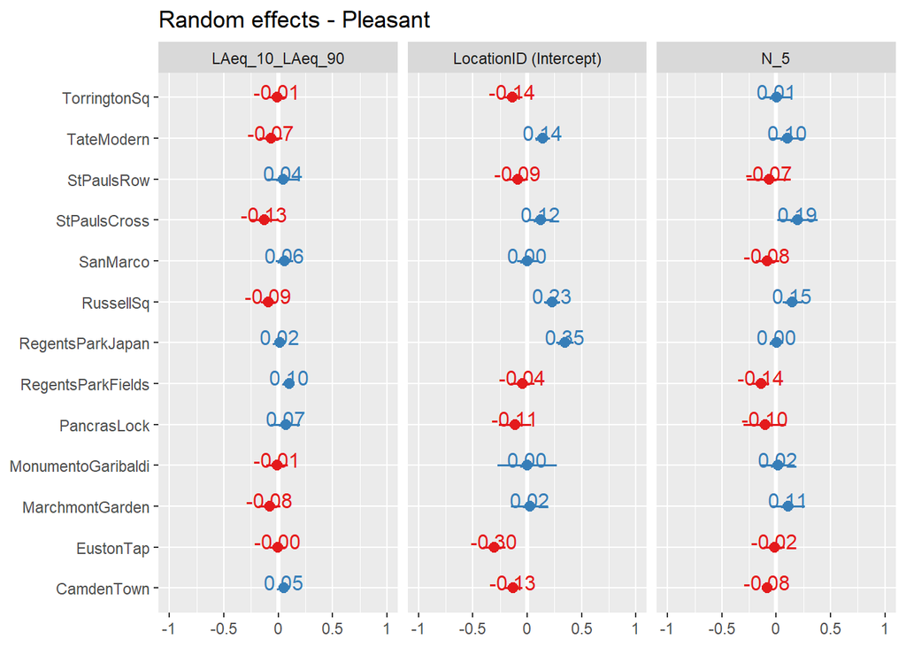

```r
sjPlot::plot_model(Pleasant_model, type="re", title = "Random effects - Pleasant", show.values = TRUE)
```

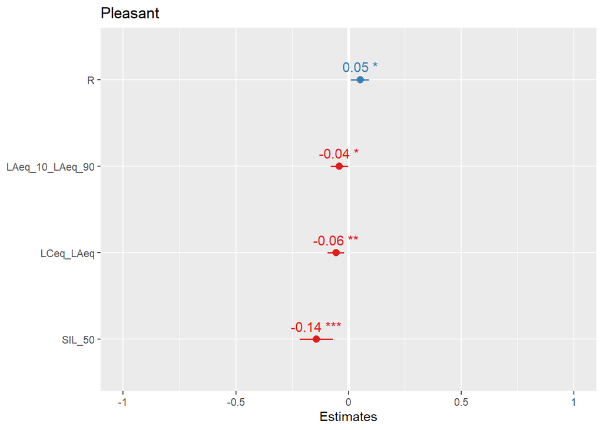

```r
sjPlot::plot_model(Pleasant_model, show.values = TRUE)
```

```r
kable(MuMIn::r.squaredGLMM(Pleasant_model))
```

| R2m | R2c |
| --- | --- |
| 0.0553483 | 0.3647619 |

## Eventful Model

```r
Eventful_formula <- as.formula(glue("Eventful ~ 1 + ", feature_string, " + (1 + ", feature_string, "|LocationID)"))

init_Eventful_model <- lmerTest::lmer(Eventful_formula, data = train)

step_Eventful_model <- lmerTest::step(init_Eventful_model, data = train)
kable(step_Eventful_model$fixed)
```

|  | Eliminated | Sum Sq | Mean Sq | NumDF | DenDF | F value | Pr(>F) |
| --- | --- | --- | --- | --- | --- | --- | --- |
| PeakSpectralCentroid | 1 | 0.0024378 | 0.0024378 | 1 | 700.46295 | 0.0309398 | 0.8604256 |
| LAeq_10_LAeq_90 | 2 | 0.0154697 | 0.0154697 | 1 | 846.85252 | 0.1965204 | 0.6576575 |
| LAeq | 3 | 0.0205971 | 0.0205971 | 1 | 853.69493 | 0.2619404 | 0.6089226 |
| I | 4 | 0.0260724 | 0.0260724 | 1 | 794.11408 | 0.3318199 | 0.5647527 |
| R | 5 | 0.1253204 | 0.1253204 | 1 | 848.22567 | 1.5959257 | 0.2068287 |
| FS | 6 | 0.2484615 | 0.2484615 | 1 | 860.92801 | 3.1606092 | 0.0757879 |
| N_5 | 7 | 0.2436875 | 0.2436875 | 1 | 423.35250 | 3.0909480 | 0.0794515 |
| LCeq_LAeq | 8 | 0.2380454 | 0.2380454 | 1 | 388.66880 | 3.0145083 | 0.0833149 |
| S | 0 | 1.4029051 | 1.4029051 | 1 | 78.51478 | 17.7360559 | 0.0000671 |
| SIL_50 | 0 | 4.2462660 | 4.2462660 | 1 | 56.62402 | 53.6828966 | 0.0000000 |

```r
kable(step_Eventful_model$random)
```

|  | Eliminated | npar | logLik | AIC | LRT | Df | Pr(>Chisq) |
| --- | --- | --- | --- | --- | --- | --- | --- |
|  | NA | 78 | -153.0276 | 462.0553 | NA | NA | NA |
| I in (1 + N_5 + S + R + I + FS + LAeq + LAeq_10_LAeq_90 + LCeq_LAeq + SIL_50 + PeakSpectralCentroid \| LocationID) | 1 | 67 | -153.8409 | 441.6818 | 1.626456 | 11 | 0.9994367 |
| N_5 in (N_5 + S + R + FS + LAeq + LAeq_10_LAeq_90 + LCeq_LAeq + SIL_50 + PeakSpectralCentroid \| LocationID) | 2 | 57 | -154.9410 | 423.8819 | 2.200166 | 10 | 0.9945630 |
| LCeq_LAeq in (S + R + FS + LAeq + LAeq_10_LAeq_90 + LCeq_LAeq + SIL_50 + PeakSpectralCentroid \| LocationID) | 3 | 48 | -155.4455 | 406.8911 | 1.009175 | 9 | 0.9994161 |
| LAeq_10_LAeq_90 in (S + R + FS + LAeq + LAeq_10_LAeq_90 + SIL_50 + PeakSpectralCentroid \| LocationID) | 4 | 40 | -156.6380 | 393.2759 | 2.384814 | 8 | 0.9668859 |
| LAeq in (S + R + FS + LAeq + SIL_50 + PeakSpectralCentroid \| LocationID) | 5 | 33 | -157.6578 | 381.3156 | 2.039714 | 7 | 0.9576096 |
| SIL_50 in (S + R + FS + SIL_50 + PeakSpectralCentroid \| LocationID) | 6 | 27 | -159.6524 | 373.3048 | 3.989218 | 6 | 0.6781356 |
| R in (S + R + FS + PeakSpectralCentroid \| LocationID) | 7 | 22 | -161.5005 | 367.0010 | 3.696190 | 5 | 0.5939310 |
| S in (S + FS + PeakSpectralCentroid \| LocationID) | 8 | 18 | -164.5490 | 365.0981 | 6.097022 | 4 | 0.1920188 |
| PeakSpectralCentroid in (FS + PeakSpectralCentroid \| LocationID) | 9 | 15 | -166.1143 | 362.2287 | 3.130630 | 3 | 0.3719198 |
| FS in (FS \| LocationID) | 10 | 13 | -167.9655 | 361.9310 | 3.702286 | 2 | 0.1570576 |
| (1 \| LocationID) | 0 | 12 | -175.2218 | 374.4437 | 14.512684 | 1 | 0.0001392 |

```r
Eventful_model <- lmerTest::get_model(step_Eventful_model)


sjPlot::tab_model(Eventful_model, show.icc = TRUE, collapse.ci = TRUE, show.aic = TRUE)
```

|  | Eventful |  |
| --- | --- | --- |
| Predictors | Estimates | p |
| (Intercept) | 0.14 (0.10 – 0.18) | **<0.001** |
| S | -0.08 (-0.12 – -0.04) | **<0.001** |
| SIL_50 | 0.14 (0.10 – 0.18) | **<0.001** |
| Random Effects |  |  |
| σ<sup>2</sup> | 0.08 |  |
| τ<sub>00</sub> <sub>LocationID</sub> | 0.00 |  |
| ICC | 0.05 |  |
| N <sub>LocationID</sub> | 13 |  |
| Observations | 879 |  |
| Marginal R<sup>2</sup> / Conditional R<sup>2</sup> | 0.125 / 0.168 |  |
| AIC | 309.030 |  |

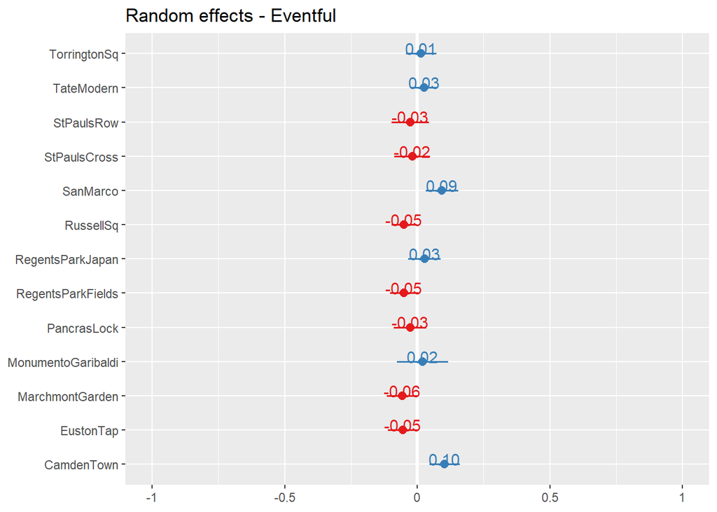

```r
sjPlot::plot_model(Eventful_model, type="re", title = "Random effects - Eventful", show.values = TRUE)
```

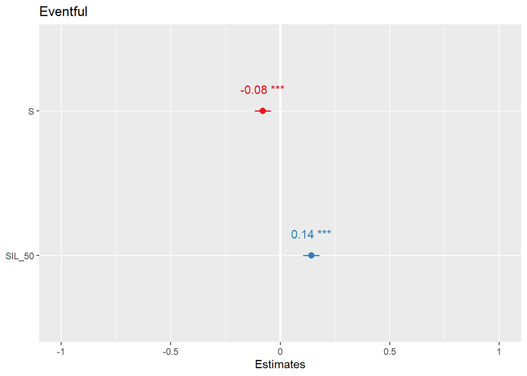

```r
sjPlot::plot_model(Eventful_model, show.values = TRUE)
```

```r
kable(MuMIn::r.squaredGLMM(Eventful_model))
```

| R2m | R2c |
| --- | --- |
| 0.125379 | 0.1678788 |

## Natural Model

```r
Natural_formula <- as.formula(glue("Natural ~ 1 + ", feature_string, " + (1 + ", feature_string, "|LocationID)"))

init_Natural_model <- lmerTest::lmer(Natural_formula, data = train)

step_Natural_model <- lmerTest::step(init_Natural_model, data = train)
kable(step_Natural_model$fixed)
```

|  | Eliminated | Sum Sq | Mean Sq | NumDF | DenDF | F value | Pr(>F) |
| --- | --- | --- | --- | --- | --- | --- | --- |
| PeakSpectralCentroid | 1 | 0.0912442 | 0.0912442 | 1 | 14.33016 | 0.1057285 | 0.7497594 |
| I | 2 | 0.1468409 | 0.1468409 | 1 | 461.27022 | 0.1701636 | 0.6801581 |
| LAeq_10_LAeq_90 | 3 | 0.3129535 | 0.3129535 | 1 | 542.31263 | 0.3629028 | 0.5471503 |
| SIL_50 | 4 | 0.0639649 | 0.0639649 | 1 | 546.62448 | 0.0741833 | 0.7854434 |
| S | 5 | 1.5929429 | 1.5929429 | 1 | 21.36462 | 1.8488248 | 0.1880984 |
| R | 6 | 0.9726176 | 0.9726176 | 1 | 591.17034 | 1.1299036 | 0.2882299 |
| N_5 | 0 | 3.6268953 | 3.6268953 | 1 | 315.41178 | 4.2127381 | 0.0409464 |
| FS | 0 | 7.3175017 | 7.3175017 | 1 | 673.55172 | 8.4994786 | 0.0036705 |
| LAeq | 0 | 27.3997899 | 27.3997899 | 1 | 141.70383 | 31.8256060 | 0.0000001 |
| LCeq_LAeq | 0 | 14.7840619 | 14.7840619 | 1 | 243.19248 | 17.1720927 | 0.0000472 |

```r
kable(step_Natural_model$random)
```

|  | Eliminated | npar | logLik | AIC | LRT | Df | Pr(>Chisq) |
| --- | --- | --- | --- | --- | --- | --- | --- |
|  | NA | 78 | -1209.021 | 2574.043 | NA | NA | NA |
| R in (1 + N_5 + S + R + I + FS + LAeq + LAeq_10_LAeq_90 + LCeq_LAeq + SIL_50 + PeakSpectralCentroid \| LocationID) | 1 | 67 | -1209.537 | 2553.075 | 1.031918 | 11 | 0.9999409 |
| N_5 in (N_5 + S + I + FS + LAeq + LAeq_10_LAeq_90 + LCeq_LAeq + SIL_50 + PeakSpectralCentroid \| LocationID) | 2 | 57 | -1210.245 | 2534.491 | 1.416413 | 10 | 0.9991729 |
| FS in (S + I + FS + LAeq + LAeq_10_LAeq_90 + LCeq_LAeq + SIL_50 + PeakSpectralCentroid \| LocationID) | 3 | 48 | -1211.077 | 2518.154 | 1.662841 | 9 | 0.9957488 |
| I in (S + I + LAeq + LAeq_10_LAeq_90 + LCeq_LAeq + SIL_50 + PeakSpectralCentroid \| LocationID) | 4 | 40 | -1212.522 | 2505.045 | 2.891192 | 8 | 0.9409990 |
| LAeq_10_LAeq_90 in (S + LAeq + LAeq_10_LAeq_90 + LCeq_LAeq + SIL_50 + PeakSpectralCentroid \| LocationID) | 5 | 33 | -1214.546 | 2495.092 | 4.047529 | 7 | 0.7742870 |
| LCeq_LAeq in (S + LAeq + LCeq_LAeq + SIL_50 + PeakSpectralCentroid \| LocationID) | 6 | 27 | -1217.021 | 2488.041 | 4.948978 | 6 | 0.5503736 |
| LAeq in (S + LAeq + SIL_50 + PeakSpectralCentroid \| LocationID) | 7 | 22 | -1218.972 | 2481.945 | 3.903351 | 5 | 0.5634134 |
| SIL_50 in (S + SIL_50 + PeakSpectralCentroid \| LocationID) | 8 | 18 | -1219.475 | 2474.951 | 1.005739 | 4 | 0.9089245 |
| S in (S + PeakSpectralCentroid \| LocationID) | 0 | 15 | -1229.983 | 2489.967 | 21.016349 | 3 | 0.0001045 |
| PeakSpectralCentroid in (S + PeakSpectralCentroid \| LocationID) | 0 | 15 | -1222.663 | 2475.326 | 6.375787 | 3 | 0.0946920 |

```r
Natural_model <- lmerTest::get_model(step_Natural_model)

sjPlot::tab_model(Natural_model, show.icc = TRUE, collapse.ci = TRUE, show.aic = TRUE)
```

|  | Natural |  |
| --- | --- | --- |
| Predictors | Estimates | p |
| (Intercept) | 2.24 (2.07 – 2.42) | **<0.001** |
| N_5 | 0.28 (0.01 – 0.54) | **0.040** |
| FS | 0.12 (0.04 – 0.19) | **0.004** |
| LAeq | -0.80 (-1.07 – -0.52) | **<0.001** |
| LCeq_LAeq | -0.22 (-0.32 – -0.12) | **<0.001** |
| Random Effects |  |  |
| σ<sup>2</sup> | 0.86 |  |
| τ<sub>00</sub> <sub>LocationID</sub> | 0.17 |  |
| τ<sub>11</sub> <sub>LocationID.S</sub> | 0.13 |  |
| τ<sub>11</sub> <sub>LocationID.PeakSpectralCentroid</sub> | 0.02 |  |
| ρ<sub>01</sub> | 0.81 |  |
|  | -0.85 |  |
| ICC | 0.16 |  |
| N <sub>LocationID</sub> | 13 |  |
| Observations | 881 |  |
| Marginal R<sup>2</sup> / Conditional R<sup>2</sup> | 0.155 / 0.293 |  |
| AIC | 2447.359 |  |

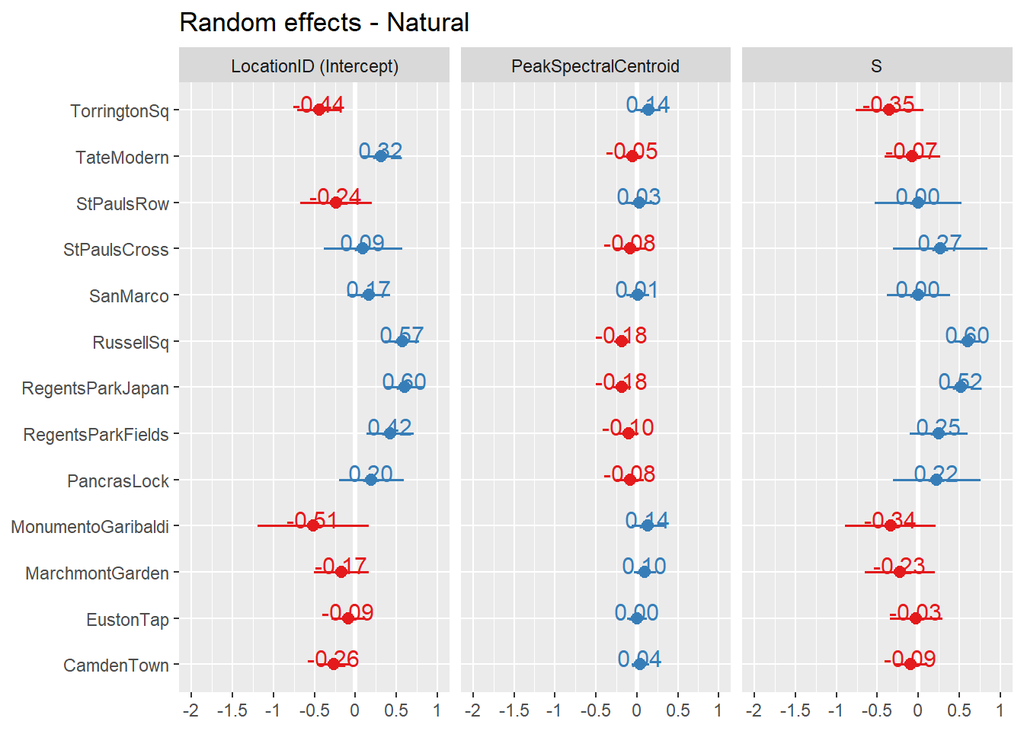

```r
sjPlot::plot_model(Natural_model, type="re", title = "Random effects - Natural", show.values = TRUE)
```

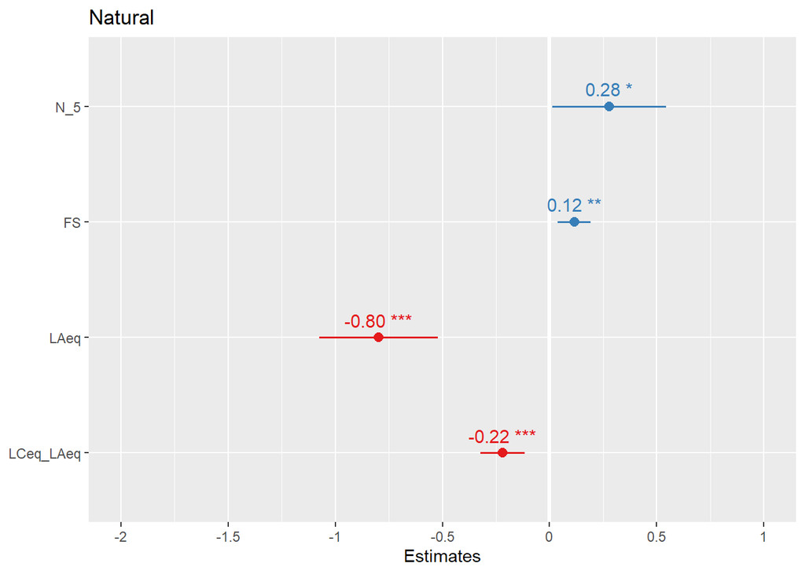

```r
sjPlot::plot_model(Natural_model, show.values = TRUE)
```

```r
kable(MuMIn::r.squaredGLMM(Natural_model))
```

| R2m | R2c |
| --- | --- |
| 0.1423133 | 0.3524638 |

## Traffic Model

```r
Traffic_formula <- as.formula(glue("Traffic ~ 1 + ", feature_string, " + (1 + ", feature_string, "|LocationID)"))

init_Traffic_model <- lmerTest::lmer(Traffic_formula, data = train)

step_Traffic_model <- lmerTest::step(init_Traffic_model, data = train)
kable(step_Traffic_model$fixed)
```

|  | Eliminated | Sum Sq | Mean Sq | NumDF | DenDF | F value | Pr(>F) |
| --- | --- | --- | --- | --- | --- | --- | --- |
| I | 1 | 0.0003888 | 0.0003888 | 1 | 228.044119 | 0.0005242 | 0.9817534 |
| PeakSpectralCentroid | 2 | 0.2302444 | 0.2302444 | 1 | 765.760532 | 0.3106605 | 0.5774380 |
| S | 3 | 0.2509525 | 0.2509525 | 1 | 182.090301 | 0.3390522 | 0.5610971 |
| LCeq_LAeq | 4 | 0.5337708 | 0.5337708 | 1 | 10.517229 | 0.7208854 | 0.4147616 |
| N_5 | 5 | 0.9051075 | 0.9051075 | 1 | 473.884016 | 1.2235547 | 0.2692254 |
| FS | 6 | 1.2186101 | 1.2186101 | 1 | 502.174277 | 1.6475231 | 0.1998884 |
| R | 0 | 3.8682758 | 3.8682758 | 1 | 9.170037 | 5.2200907 | 0.0476709 |
| LAeq | 0 | 7.6731074 | 7.6731074 | 1 | 51.657351 | 10.3545658 | 0.0022323 |
| LAeq_10_LAeq_90 | 0 | 4.0188937 | 4.0188937 | 1 | 634.596050 | 5.4233438 | 0.0201824 |
| SIL_50 | 0 | 4.7951129 | 4.7951129 | 1 | 25.155356 | 6.4708219 | 0.0174822 |

```r
kable(step_Traffic_model$random)
```

|  | Eliminated | npar | logLik | AIC | LRT | Df | Pr(>Chisq) |
| --- | --- | --- | --- | --- | --- | --- | --- |
|  | NA | 78 | -1160.883 | 2477.765 | NA | NA | NA |
| N_5 in (1 + N_5 + S + R + I + FS + LAeq + LAeq_10_LAeq_90 + LCeq_LAeq + SIL_50 + PeakSpectralCentroid \| LocationID) | 1 | 67 | -1162.011 | 2458.023 | 2.257526 | 11 | 0.9973673 |
| S in (S + R + I + FS + LAeq + LAeq_10_LAeq_90 + LCeq_LAeq + SIL_50 + PeakSpectralCentroid \| LocationID) | 2 | 57 | -1163.247 | 2440.494 | 2.471096 | 10 | 0.9912903 |
| PeakSpectralCentroid in (R + I + FS + LAeq + LAeq_10_LAeq_90 + LCeq_LAeq + SIL_50 + PeakSpectralCentroid \| LocationID) | 3 | 48 | -1164.436 | 2424.871 | 2.377825 | 9 | 0.9839907 |
| I in (R + I + FS + LAeq + LAeq_10_LAeq_90 + LCeq_LAeq + SIL_50 \| LocationID) | 4 | 40 | -1166.804 | 2413.609 | 4.737332 | 8 | 0.7852460 |
| LAeq_10_LAeq_90 in (R + FS + LAeq + LAeq_10_LAeq_90 + LCeq_LAeq + SIL_50 \| LocationID) | 5 | 33 | -1169.817 | 2405.635 | 6.025878 | 7 | 0.5367309 |
| FS in (R + FS + LAeq + LCeq_LAeq + SIL_50 \| LocationID) | 6 | 27 | -1173.114 | 2400.228 | 6.593288 | 6 | 0.3601009 |
| R in (R + LAeq + LCeq_LAeq + SIL_50 \| LocationID) | 0 | 22 | -1179.571 | 2403.141 | 12.913228 | 5 | 0.0242056 |
| LAeq in (R + LAeq + LCeq_LAeq + SIL_50 \| LocationID) | 0 | 22 | -1181.622 | 2407.243 | 17.015287 | 5 | 0.0044709 |
| LCeq_LAeq in (R + LAeq + LCeq_LAeq + SIL_50 \| LocationID) | 0 | 22 | -1181.582 | 2407.164 | 16.935558 | 5 | 0.0046236 |
| SIL_50 in (R + LAeq + LCeq_LAeq + SIL_50 \| LocationID) | 0 | 22 | -1181.413 | 2406.825 | 16.597127 | 5 | 0.0053308 |

```r
Traffic_model <- lmerTest::get_model(step_Traffic_model)

sjPlot::tab_model(Traffic_model, show.icc = TRUE, collapse.ci = TRUE, show.aic = TRUE)
```

|  | Traffic |  |
| --- | --- | --- |
| Predictors | Estimates | p |
| (Intercept) | 2.80 (2.43 – 3.17) | **<0.001** |
| R | 0.25 (0.04 – 0.46) | **0.022** |
| LAeq | -0.95 (-1.53 – -0.37) | **0.001** |
| LAeq_10_LAeq_90 | 0.15 (0.02 – 0.27) | **0.020** |
| SIL_50 | 0.82 (0.19 – 1.44) | **0.011** |
| Random Effects |  |  |
| σ<sup>2</sup> | 0.74 |  |
| τ<sub>00</sub> <sub>LocationID</sub> | 0.46 |  |
| τ<sub>11</sub> <sub>LocationID.R</sub> | 0.11 |  |
| τ<sub>11</sub> <sub>LocationID.LAeq</sub> | 1.01 |  |
| τ<sub>11</sub> <sub>LocationID.LCeq_LAeq</sub> | 0.06 |  |
| τ<sub>11</sub> <sub>LocationID.SIL_50</sub> | 1.17 |  |
| ρ<sub>01</sub> | -0.18 |  |
|  | -0.12 |  |
|  | -0.36 |  |
|  | 0.13 |  |
| N <sub>LocationID</sub> | 13 |  |
| Observations | 881 |  |
| Marginal R<sup>2</sup> / Conditional R<sup>2</sup> | 0.045 / NA |  |
| AIC | 2370.332 |  |

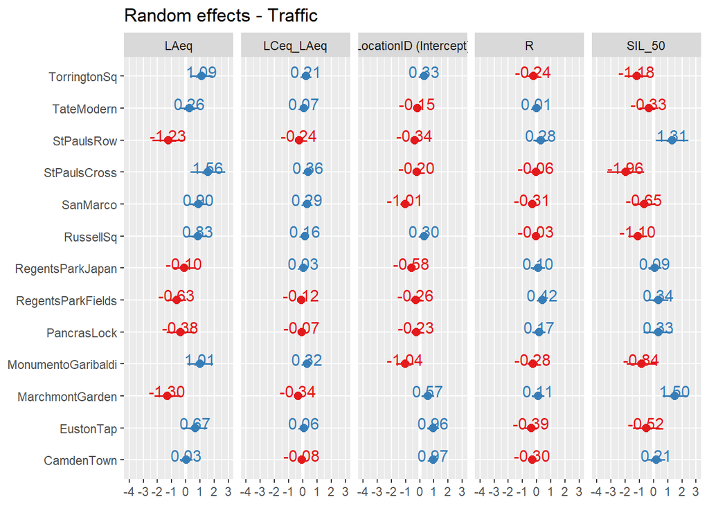

```r
sjPlot::plot_model(Traffic_model, type="re", title = "Random effects - Traffic", show.values = TRUE)
```

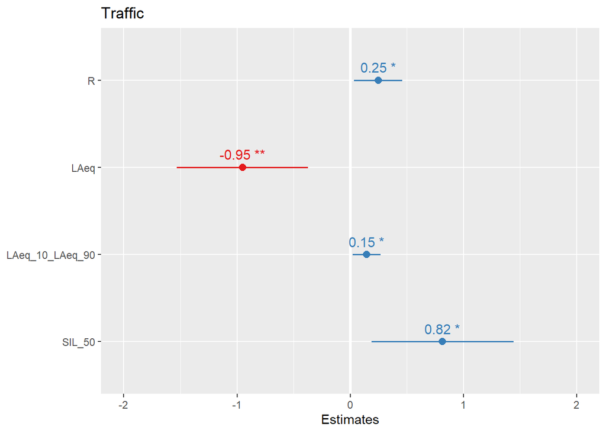

```r
sjPlot::plot_model(Traffic_model, show.values = TRUE)
```

```r
kable(MuMIn::r.squaredGLMM(Traffic_model))
```

| R2m | R2c |
| --- | --- |
| 0.0240186 | 0.4939373 |

## Human Model

```r
Human_formula <- as.formula(glue("Human ~ 1 + ", feature_string, " + (1 + ", feature_string, "|LocationID)"))

init_Human_model <- lmerTest::lmer(Human_formula, data = train)

step_Human_model <- lmerTest::step(init_Human_model, data = train)
kable(step_Human_model$fixed)
```

|  | Eliminated | Sum Sq | Mean Sq | NumDF | DenDF | F value | Pr(>F) |
| --- | --- | --- | --- | --- | --- | --- | --- |
| LCeq_LAeq | 1 | 0.0095495 | 0.0095495 | 1 | 789.49094 | 0.0132964 | 0.9082286 |
| S | 2 | 0.2120699 | 0.2120699 | 1 | 567.93480 | 0.2956512 | 0.5868350 |
| R | 3 | 0.2232364 | 0.2232364 | 1 | 783.99536 | 0.3116436 | 0.5768327 |
| FS | 4 | 0.2768007 | 0.2768007 | 1 | 595.99874 | 0.3866007 | 0.5343294 |
| LAeq | 5 | 0.2922824 | 0.2922824 | 1 | 29.53664 | 0.4085720 | 0.5276217 |
| LAeq_10_LAeq_90 | 6 | 0.7602528 | 0.7602528 | 1 | 160.95789 | 1.0628302 | 0.3041172 |
| N_5 | 7 | 2.6782958 | 2.6782958 | 1 | 133.63532 | 3.7406857 | 0.0552163 |
| SIL_50 | 8 | 1.7427104 | 1.7427104 | 1 | 9.96460 | 2.4296753 | 0.1502243 |
| I | 0 | 6.0597930 | 6.0597930 | 1 | 698.87055 | 8.4522257 | 0.0037615 |
| PeakSpectralCentroid | 0 | 3.3347980 | 3.3347980 | 1 | 715.07188 | 4.6513907 | 0.0313611 |

```r
kable(step_Human_model$random)
```

|  | Eliminated | npar | logLik | AIC | LRT | Df | Pr(>Chisq) |
| --- | --- | --- | --- | --- | --- | --- | --- |
|  | NA | 78 | -1139.497 | 2434.994 | NA | NA | NA |
| S in (1 + N_5 + S + R + I + FS + LAeq + LAeq_10_LAeq_90 + LCeq_LAeq + SIL_50 + PeakSpectralCentroid \| LocationID) | 1 | 67 | -1139.577 | 2413.155 | 0.1604611 | 11 | 1.0000000 |
| R in (N_5 + R + I + FS + LAeq + LAeq_10_LAeq_90 + LCeq_LAeq + SIL_50 + PeakSpectralCentroid \| LocationID) | 2 | 57 | -1139.921 | 2393.841 | 0.6866450 | 10 | 0.9999701 |
| LAeq_10_LAeq_90 in (N_5 + I + FS + LAeq + LAeq_10_LAeq_90 + LCeq_LAeq + SIL_50 + PeakSpectralCentroid \| LocationID) | 3 | 48 | -1140.435 | 2376.870 | 1.0281820 | 9 | 0.9993698 |
| FS in (N_5 + I + FS + LAeq + LCeq_LAeq + SIL_50 + PeakSpectralCentroid \| LocationID) | 4 | 40 | -1140.955 | 2361.910 | 1.0401412 | 8 | 0.9979818 |
| N_5 in (N_5 + I + LAeq + LCeq_LAeq + SIL_50 + PeakSpectralCentroid \| LocationID) | 5 | 33 | -1141.675 | 2349.350 | 1.4397748 | 7 | 0.9843217 |
| LCeq_LAeq in (I + LAeq + LCeq_LAeq + SIL_50 + PeakSpectralCentroid \| LocationID) | 6 | 27 | -1142.491 | 2338.981 | 1.6315764 | 6 | 0.9502805 |
| I in (I + LAeq + SIL_50 + PeakSpectralCentroid \| LocationID) | 7 | 22 | -1143.305 | 2330.610 | 1.6288557 | 5 | 0.8977380 |
| PeakSpectralCentroid in (LAeq + SIL_50 + PeakSpectralCentroid \| LocationID) | 8 | 18 | -1143.457 | 2322.914 | 0.3036337 | 4 | 0.9895784 |
| LAeq in (LAeq + SIL_50 \| LocationID) | 0 | 15 | -1147.502 | 2325.004 | 8.0906462 | 3 | 0.0441750 |
| SIL_50 in (LAeq + SIL_50 \| LocationID) | 0 | 15 | -1146.653 | 2323.307 | 6.3929662 | 3 | 0.0939806 |

```r
Human_model <- lmerTest::get_model(step_Human_model)

sjPlot::tab_model(Human_model, show.icc = TRUE, collapse.ci = TRUE, show.aic = TRUE)
```

|  | Human |  |
| --- | --- | --- |
| Predictors | Estimates | p |
| (Intercept) | 2.97 (2.75 – 3.19) | **<0.001** |
| I | 0.10 (0.03 – 0.17) | **0.004** |
| PeakSpectralCentroid | -0.08 (-0.14 – -0.01) | **0.031** |
| Random Effects |  |  |
| σ<sup>2</sup> | 0.72 |  |
| τ<sub>00</sub> <sub>LocationID</sub> | 0.27 |  |
| τ<sub>11</sub> <sub>LocationID.LAeq</sub> | 0.32 |  |
| τ<sub>11</sub> <sub>LocationID.SIL_50</sub> | 0.33 |  |
| ρ<sub>01</sub> | -0.21 |  |
|  | 0.46 |  |
| ICC | 0.27 |  |
| N <sub>LocationID</sub> | 13 |  |
| Observations | 881 |  |
| Marginal R<sup>2</sup> / Conditional R<sup>2</sup> | 0.015 / 0.282 |  |
| AIC | 2288.832 |  |

[figure not shown]

```r
sjPlot::plot_model(Human_model, type="re", title = "Random effects - Traffic", show.values = TRUE)
```

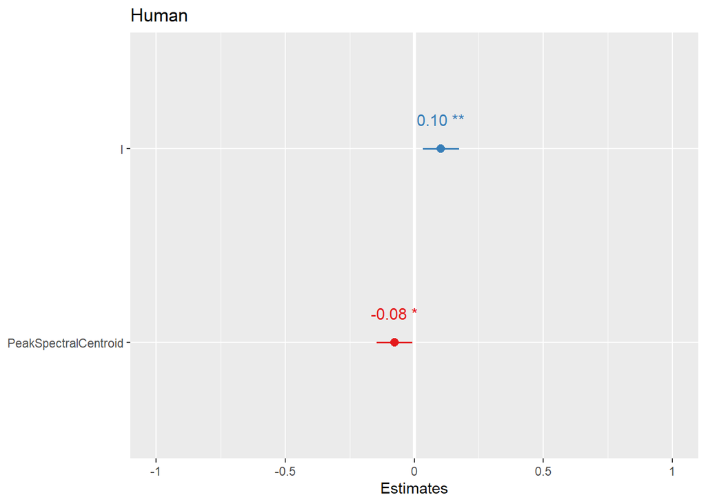

```r
sjPlot::plot_model(Human_model, show.values = TRUE)
```

```r
kable(MuMIn::r.squaredGLMM(Human_model))
```

| R2m | R2c |
| --- | --- |
| 0.0142053 | 0.3146794 |